# IoT - Kurs

Draft

# Motivation

Arduino und IoT sind sexy Themen für Lernende. Praxisnahe Anwendungsprojekte mit massiver Verlinkung bereits bekannter Inhalte anderer Module steigern die Motivation und fördern das modulübergreifende Verständnis.

Die ICT-HANOKs können ohne die harzige Assembler-Sprache vermittelt werden.

# Standortspezifische Hinweise

M242 wird je nach Standort entweder im 2. oder 4. Semester unterrichtet. Entsprechend **werden für das 2. Semester die Ziele angepasst**. Insbesondere das Erstellen serverseitiger Applikationen zur Auswertung der gesendeten IoT-Nachrichten kann über vorgefertigte Server-Apps erfolgen.

# 1 Aufbau der Projektwoche

1. kurzer Überblick Programmablauf
2. Einführung: Was ist IoT, Live-Demos demonstrieren (1h)
3. Workshops / Posten (7 + 8h)
4. Projekte (22h+nächtliches Hacking (requires Pizza+Kaffee))
5. Präsentationen und Abschluss (2h)

# 2 Demos

- Wetterdaten weltweit (mit Historie, Aktuelle Vorhersage): http://openweathermap.org/
- http://www.buildinginternetofthings.com/list-of-projects/
- https://scanlibs.com/internet-things-arduino-cookbook/

# 3 Lehrvorträge / Posten

## 3.1 Intro Mikroprozessoren / Sensoren (8 Lektionen)

1. Kurzvortrag (max. 30 Minuten)
   - Demo IoT
   - Arduino IDE vorstellen
2. Mini-Projekte mit Breadboards, LEDS, Tastern
3. Kurzvortrag (max. 30 Minuten)
   - aktive, passive Sensoren / Aktoren Grundlagen
   - Arduino Bibliotheken für aktive Sensoren, LCDs
4. Mini-Projekte mit Breadboards, Sensoren, Aktor (Lüfter via Transistor?) + LCD-Display-Miniprojekt (2h)

?? Löten oder nicht ?? Elektronik Grundlagen?

## 3.2 Intro Mikroprozessor-Architektur (4 Lektionen)

1. Kurzvortrag Konzept Microcontroller (vs. PC)
   - Register,...
   - [SimulAVR](https://www.mikrocontroller.net/articles/AVR-Simulation), [WDR-Papiercomputer](http://www.wolfgang-back.com/knowhow_home.php)
   - /home/sven/apps/papiercomputer/khcback.exe
2. Kurzprojekt SimulAVR
   - Programmieren mit Registern
   - Mini-Projekt alà http://www.instructables.com/id/Command-Line-Assembly-Language-Programming-for-Ard/
3. Kurzvortrag Interrupts und Sleep-Mode (20 min)
   - Mini-Projekt Arduino-Interrupt - Programmierung
4. Bus Systeme (I²C, SPI, etc.)

## 3.3 Intro Kommunikation Mikrocotroller - PC (4 Lektionen)

- Kurzvortrag (max. 30 Minuten)
  - UART... was notwendig ist, um HANOKs abzudecken
  - Seriell (am einfachsten und schnellsten)
  - WLAN-basiert
- Mini-Projekt (2-3 h)

## 3.3 @WISS 4. Semester: Webserver mit PHP und Datenbanken (Raspberry)

- PHP, HTML, MySQL gut bekannt
- Client-Server Architektur teilweise bekannt
- Mini-Projekt: Sensordaten vom Arduino auf Pi laden, visualisieren mit Web-UI (4h)

# 4 Projekte

## 4.1 Raumtemperatur/Feuchtigkeitsüberwachung mit Remote-Logging & Alarm

- Lüfter anschalten bei Übertemperatur (mc-kontrolliert)
- Raumluft-Qualität messen
- Webserver-basiertes Monitoring (grafische Anzeige)

## 4.2 Heim-Automation

- Pflanzenbewässerung

## 4.3 kombinierte RFID und Zahlencode-basierte Zugangskontrolle

- mit Remote-Logging & Remote-Deaktivierung
- Webserver-basiertes Monitoring (grafische Anzeige), z.B. Webcam aktivieren bei falscher Pin-Eingabe oder nicht vorhandener RFID
- optional: Einmalcodes vom Server

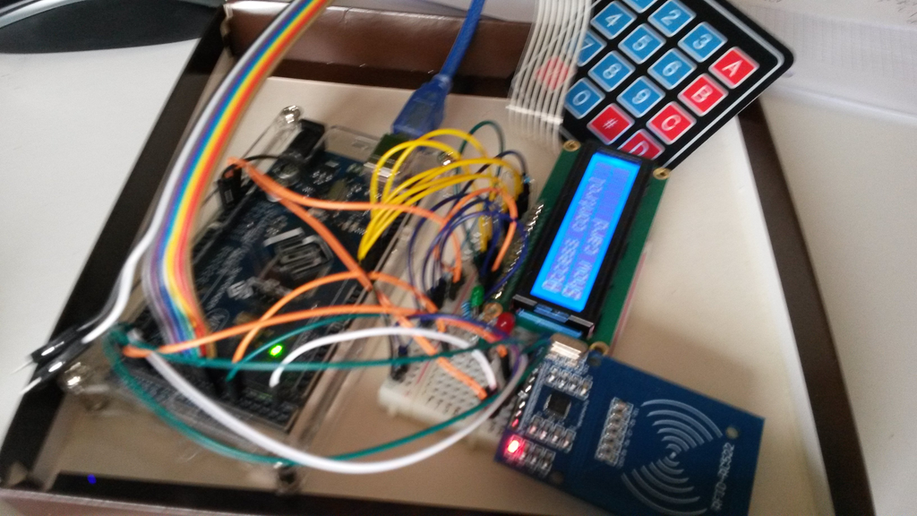

## 4.4 Arduino-basiertes Leistungsmessgerät für Niedervolt-Geräte

- Spannung+Strom für 5/12V Strecke im PC messen
- Ausgabe auf Display
- Webserver-basiertes Monitoring (grafische Anzeige)

## 4.5 Multiplayer - Game

- mit Gyroskop-WLAN Things (alà Wii)
- Robigame via GameServer
- Force-Feedback (mobile vibration stuff)

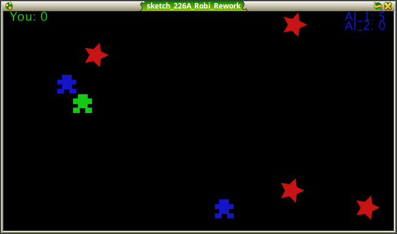

## 4.5 Projektarbeit (2. Semester)

- es bestehen elementare Vorkenntnisse über HTTP (M101)
- Projekte siehe oben, allenfalls Remote-Logging unter Nutzung vorhandener IoT-Webplattformen, z.B. https://dweet.io/

## 4.5 Fachbereichsübergreifende Projektarbeit (4. Semester)

**Ziel:** Die Lernenden erstellen in Zweier/Dreier-Gruppen ein WIFI-basiertes Netzwerk mit "intelligenten" Sensoren/Aktoren und Webserver-basierten Daten-Logging / Monitoring zur Anwendung und Vertiefung der theoretischen Kenntnisse über Mikrocontroller.

**Vorkentnisse:** Die Lernenden (API und SYS) haben Vorkentnisse in folgenden Themen:

- HTML, PHP, JS (API)
- Netzwerke (WiFi) einrichten (SYS)
- Webserver und Datenbankserver betreiben (API/SYS)
- Strom und Spannungen messen (Modul ??)

## 4.6 Durchführung

# 5 Benötigte Hardware

## 5.1 TODO: Entscheidung

- Arduino UNO R3 + Ethernet-Shield mit SD-Card Slot
  - http://www.mikroshop.ch/Warenkorb.html?gruppe=3&artikel=501
  - http://www.mikroshop.ch/Warenkorb.html?gruppe=3&artikel=849
  - unter 20 Fr (!)
  - 20 DI/O
  - 6 AI
  - U=5V, I=40mA je DO - Atmel AVR, 8bit
- Arduino Feather HUZZAH ESP8266 (15$ ??)
  - integriertes WIFI
  - Beardboard kompatibel
  - 9 DI/O (SPI, I2C
  - 1 AI
  - 3.3V; 7mA je DO
  - onboard battery charger
- Alternative: Arduino UNO WiFi (UNO kompatibel) (ca. 43 Fr/Stück)
  - https://blog.play-zone.ch/2016/06/01/arduino-wifi/2/
  - 20 DI/O
  - 6 AI
  - U=5V, I=40mA je DO
  - onboard ESP8266 mit 4MB flash, 8MB instruction + 12MB data memory - Atmel AVR, 8bit
- Alternative: Genuino MKR1000 (inkl. WiFi); ca 45 Fr/Stück (playzone.ch)
  - http://www.play-zone.ch/de/genuino-mkr1000.html
  - löten!
  - 8 DI/O
  - 7 AI, 1 AO
  - 3.3V; 7mA je DO
  - 256kB Flash, 32kB SRAM
  - 32bit controller
- Ausblick Miniatur-Versionen (Arduino-Mini)
  - für produktionsreife Prototypen...

## 5.2 Zubehör

je Team:

- Sensorshield (Komplettpaket mit Temp, Feucht, Poti IR uvm.); http://www.play-zone.ch/de/sensor-und-io-shield-fur-arduino.html
- alternativ (Fun-Faktor!)
  - DHT11 Temp, Feucht.. Sensoren (ca. 3 Fr/Stück)
  - LEDs, Widerstände, Breadboards, Breadboard Kabelsätze (sollte vorhanden sein)
- LCD Display 16x2 http://mikroshop.ch/LED_LCD.html?gruppe=7&artikel=15
- RFID Sensor + Karten; ca. 17 Fr; http://www.play-zone.ch/de/mfrc522-rfid-reader-breakout-inkl-2-keys.html
- PC's mit Bastelfestplatte für Web/Datenbankserver + Arduino IDE (am einfachsten mit Debian8 oder (X)Ubuntu1604)

für gesamte Klasse: ein konfigurierbarer WLAN-Accesspoint mit LAN-Anschlüssen (sollte vorhanden sein)

# 6 IoT - eine weniger nerdige Literaturrecherche

## 6.1 Was ist IoT

- intelligente Sensoren und Aktoren, die miteiander und dem Internet kommunizieren

## 6.2 Herkunft

"The IoT has its **technological roots in the decades-long effort to monitor and control the physical environment** in which people work and play. Its most basic components are embedded devices that **have existed for years: thermostats** that sense ambient temperature and control heating and cooling systems, **sensors that manage braking systems in automobiles (ABS)**, **pacemakers that regulate the heart**, airplane black boxes that track flight paths, and location devices that monitor the whereabouts of industrial equipment. In the past, some of these devices were wired together into more complex systems. But it wasn’t until they were provided with some intelligence, connected to the Internet, and empowered by a new wave of technological accessibility—through cloud computing, smartphones, and the prototyping capabilities of digital fabrication—that the IoT came into being."

[Quelle: http://www.strategy-business.com/article/00294?gko=a9303](http://www.strategy-business.com/article/00294?gko=a9303)

## 6.3 Beispiel: NEST Learning Thermostat

- reguliert Heizleistung für Wohnräume ggf. in Abhängigkeit von Luftfeuchtigkeit, Aussentemperatur, Helligkeit...
- lernt Benutzervorlieben
- Steuerung per Smartphone
- Leistung zu Peak-Zeiten reduzieren

## 6.4 IoT aus Business-Sicht

"By **2020**, an estimated **50 billion devices** around the globe will be **connected to the Internet**. Perhaps a third of them will be computers, smartphones, tablets, and TVs. The remaining **two-thirds will be** other kinds of “things”: **sensors, actuators, and newly invented intelligent devices that monitor, control, analyze, and optimize our world.**"

"The arrival of the “Internet of Things” (IoT) represents a transformative shift for the economy, similar to the introduction of the PC itself. It **incorporates other major technology industry trends** such as cloud computing, data analytics, and mobile communications, but goes beyond them. Unlike earlier efforts to track and control large systems, such as radio-frequency identification (RFID), the Internet connection gives this shift almost limitless versatility."

"Much early work is likely to focus on boosting efficiency and cutting costs, but the greatest long-term business value of the Internet of Things will involve **getting to know customers** - both consumers and businesses - **more intimately**, and providing new digital services and experiences to delight them."

[Quelle: http://www.strategy-business.com/article/00294?gko=a9303](http://www.strategy-business.com/article/00294?gko=a9303)

**Ergo: IoT ist Big (Brother) Business.**

## 6.5 Contra: IoT - Makerszene**

- mit 3D-Druckern, Lasercuttern, preiswerter Microcontroller-Hardware und Open-Source selbst IoT-Dinge basteln
- Kontrolle über eigene Daten behalten
- Gegenpol zur Wegwerf- und Konsumgesellschaft

## 6.6 Aufbau IoT - Netze

### 6.6.1 1. Endpoints (Sensoren, Aktoren)

```
- (ehemals) passive Sensoren: z.B. Thermometer, Spannungsmesser etc.
- IoT: passive Sensoren via Mikrocontroller mit Aussenwelt verbunden
- Aktoren: Relais, Leuchten, Motoren, Türöffner etc, ebenfalls via Microcontroller mit Aussenwelt verbunden
```

### 6.6.2 2. Simple Hubs (verbinden Endpoints mit Aussenwelt/Internet)

```
- ein Hub für eine Sensoren-Art
```

### 6.6.3 3. Integrating Hubs (verbinden verschiedene Simple Hubs)

```
- intelligentes Haus: Zur Schlafenszeit werden alle Lichter gelöscht, Wohnung verriegelt etc. (Apple HomeKit)
- quantifyed self: Daten von Schrittzähler, Pulsmesser, Hautwiderstand, Schlafrhythmus etc. zusammenfassen für umfassendes Gesundheitsbild
```

### 6.6.4 4. Network & Cloud Services

```
- liefern Infrastruktur für IoT
- zuständig für Datenanalyse, SocialMedia sharing etc.
```

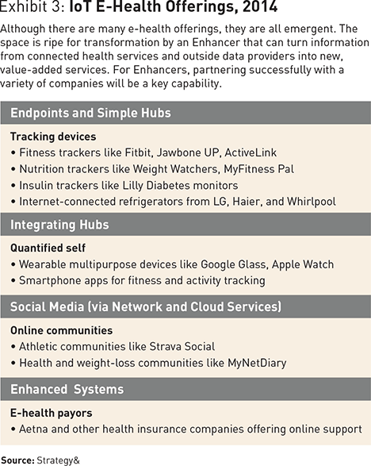

Beispiel IoT E-Health, [Quelle: http://www.strategy-business.com/article/00294?gko=a9303](http://www.strategy-business.com/article/00294?gko=a9303)

## 6.7 The Players

Der IoT-Markt besteht im wesentlichen aus folgenden Anbietern:

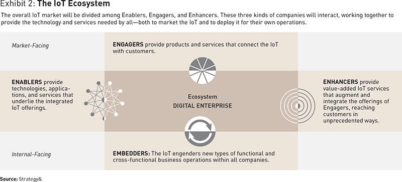

IoT-Anbieter: Rollen, [Quelle: http://www.strategy-business.com/article/00294?gko=a9303](http://www.strategy-business.com/article/00294?gko=a9303)

## 6.8 Why IoT-Strategies fail (allenfalls informativ)

1. Insufficient Investment in Project Management
2. Failure to Get Buy-In Across the Organization
3. Not Being Able to Update or Replace IoT Components
4. Underestimating Vendor Risk
5. Not Having a Plan B or an Exit Strategy
6. Downplaying Security and Privacy Threats
7. Focusing on Technology over Business

[Quelle: http://www.ioti.com/iot-trends-and-analysis/how-not-manage-iot-project-7-common-pitfalls](http://www.ioti.com/iot-trends-and-analysis/how-not-manage-iot-project-7-common-pitfalls)

## 6.9 Sicherheit (kurze Sensibilisierung)

- aktuell: ungesicherte *things* werden für gewaltige Bot-Netze gekapert

## 6.10 Energiebedarf (kurze Sensibilisierung)

Inzwischen seien weltweit etwa 14 Milliarden Geräte mit dem Netz verbunden. Allein 2013 kamen diese Geräte so auf einen Verbrauch von rund 616 Terawattstunden (TWh) – von denen fast zwei Drittel, etwa 400 TWh, verschwendet worden sein sollen. Zum Vergleich: Das entspricht dem gesamten, kombinierten Jahresbedarf an Energie von Großbritannien und Norwegen. Laut IEA summiert sich der Verlust auf 80 Milliarden US-Dollar, bis 2020 soll er sich noch auf 120 Milliarden US-Dollar erhöhen.

### 6.10.1 Ursachen:

- sparsamerer Standby-Modus nicht implementiert
- Verbindung mit dem Internet ohne Unterbrechung aufrecht erhalten
- Computer regeln zwar den Verbrauch intelligent, heben diesen Gewinn jedoch selbst wieder auf
- Rechner, die auch in der Nacht laufen oder Switches und Hubs, die gerade niemand braucht.

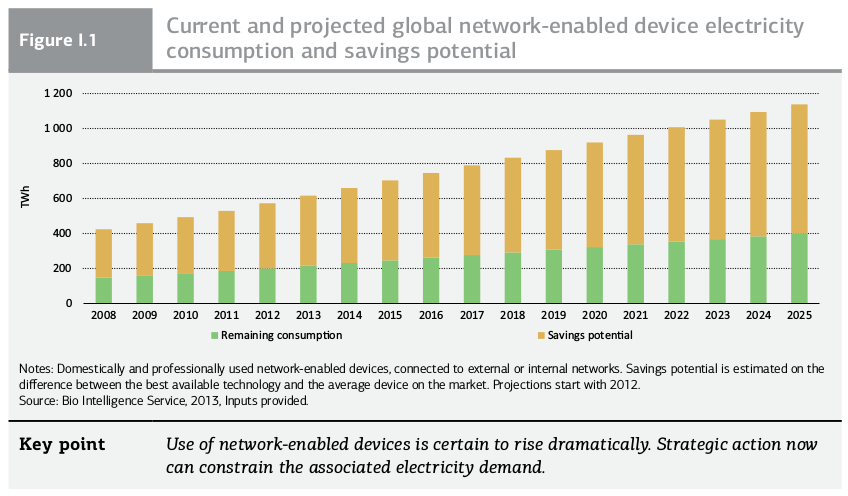

IoT-Energyverbrauch vs. Einsparung, [Quelle: http://www.heise.de/ix/meldung/Studie-Internet-of-Things-frisst-zunehmend-Energie-2250476.html](http://www.heise.de/ix/meldung/Studie-Internet-of-Things-frisst-zunehmend-Energie-2250476.html)